# *Please see the below instructions for the final group project:*

Select two of the techniques that you learned during the course. One technique should be related to Deep Learning Neural Networks and the second technique should be a Machine Learning technique **(not Neural Networks)**

1. Select the dataset (the subject) that you would like to analyze.
2. Build, train and evaluate your two different models.
3. Tune both models to optimize the results.
4. Compare and discuss the results of the two selected techniques. **Submit three items: **
   1. Audio (narrated) PowerPoint presentation
   2. The code of the two models (.py files)
   3. Screenshots for the outputs of your two models.

**Goal:**

This assignment will help you apply the techniques learned throughout the class. You will train a model using one of the Machine Learning techniques (such as k-Nearest Neighbors and Decision Trees) and check the model’s performance. Then create and train a second model using Deep Learning Neural Networks to see how the model accuracy changes.

# The question this analysis seeks to answer is: Can we predict a songs popularity based on shared or similar numerical meta data such as Danceability, Tempo, Acousticness, etc.?

# To initiate the analysis we will install the functions for an in-dept EDA & modeling

# Data Description

## Data Source

https://www.kaggle.com/datasets/maharshipandya/-spotify-tracks-dataset

## Data Dictionary

Column Description

- **track_id:** The Spotify ID for the track
- **artists:** The artists' names who performed the track. If there is more than one artist, they are separated by a ;
- **album_name:** The album name in which the track appears
- **track_name:** Name of the track
- **popularity:** The popularity of a track is a value between 0 and 100, with 100 being the most popular. The popularity is calculated by algorithm and is based, in the most part, on the total number of plays the track has had and how recent those plays are. Generally speaking, songs that are being played a lot now will have a higher popularity than songs that were played a lot in the past. Duplicate tracks (e.g. the same track from a single and an album) are rated independently. Artist and album popularity is derived mathematically from track popularity.
- **duration_ms:** The track length in milliseconds
- **explicit:** Whether or not the track has explicit lyrics (true = yes it does; false = no it does not OR unknown)
- **danceability:** Danceability describes how suitable a track is for dancing based on a combination of musical elements including tempo, rhythm stability, beat strength, and overall regularity. A value of 0.0 is least danceable and 1.0 is most danceable
- **energy:** Energy is a measure from 0.0 to 1.0 and represents a perceptual measure of intensity and activity. Typically, energetic tracks feel fast, loud, and noisy. For example, death metal has high energy, while a Bach prelude scores low on the scale
- **key:** The key the track is in. Integers map to pitches using standard Pitch Class notation. E.g. 0 = C, 1 = C♯/D♭, 2 = D, and so on. If no key was detected, the value is -1
- **loudness:** The overall loudness of a track in decibels (dB)
- **mode:** Mode indicates the modality (major or minor) of a track, the type of scale from which its melodic content is derived. Major is represented by 1 and minor is 0
- **speechiness:** Speechiness detects the presence of spoken words in a track. The more exclusively speech-like the recording (e.g. talk show, audio book, poetry), the closer to 1.0 the attribute value. Values above 0.66 describe tracks that are probably made entirely of spoken words. Values between 0.33 and 0.66 describe tracks that may contain both music and speech, either in sections or layered, including such cases as rap music. Values below 0.33 most likely represent music and other non-speech-like tracks
- **acousticness:** A confidence measure from 0.0 to 1.0 of whether the track is acoustic. 1.0 represents high confidence the track is acoustic
- **instrumentalness:** Predicts whether a track contains no vocals. "Ooh" and "aah" sounds are treated as instrumental in this context. Rap or spoken word tracks are clearly "vocal". The closer the instrumentalness value is to 1.0, the greater likelihood the track contains no vocal content
- **liveness:** Detects the presence of an audience in the recording. Higher liveness values represent an increased probability that the track was performed live. A value above 0.8 provides strong likelihood that the track is live
- **valence:** A measure from 0.0 to 1.0 describing the musical positiveness conveyed by a track. Tracks with high valence sound more positive (e.g. happy, cheerful, euphoric), while tracks with low valence sound more negative (e.g. sad, depressed, angry)
- **tempo:** The overall estimated tempo of a track in beats per minute (BPM). In musical terminology, tempo is the speed or pace of a given piece and derives directly from the average beat duration
- **time_signature:** An estimated time signature. The time signature (meter) is a notational convention to specify how many beats are in each bar (or measure). The time signature ranges from 3 to 7 indicating time signatures of 3/4, to 7/4
- **track_genre:** The genre in which the track belongs

```python
            # If Needed: Install the libraries for in-depth EDA & modeling
#!pip install tensorflow
#!pip install scikeras
#!pip install imbalanced-learn
#!pip install openpyxl
#!pip install -U scikit-learn scikeras
#!pip install pydotplus
```

# Importing the relevant packages - MC Started

```python
from scikeras.wrappers import KerasClassifier
from tensorflow.keras.models import load_model
from tensorflow.keras import backend as K
```

```python
import pandas as pd
import numpy as np
import matplotlib.pyplot as plt
import seaborn as sns
from pandas.plotting import scatter_matrix
from sklearn.utils.validation import check_X_y
from sklearn.model_selection import train_test_split, RandomizedSearchCV, GridSearchCV
from sklearn.preprocessing import StandardScaler, TargetEncoder
from sklearn.metrics import classification_report, confusion_matrix, ConfusionMatrixDisplay, accuracy_score, precision_score
from sklearn.metrics import make_scorer, roc_auc_score, average_precision_score, recall_score, f1_score, roc_curve, auc
from sklearn.tree import DecisionTreeClassifier, plot_tree
from sklearn.utils import resample
from sklearn.cluster import KMeans
from sklearn.ensemble import RandomForestRegressor, RandomForestClassifier
from sklearn.inspection import permutation_importance
from keras.models import Sequential
from keras.layers import Dense
from keras.utils import to_categorical
import warnings
warnings.filterwarnings('ignore')
from imblearn.over_sampling import SMOTE
import tensorflow as tf
tf.config.run_functions_eagerly(True)  # ensures predict() and numpy() work properly
from tensorflow.keras.callbacks import EarlyStopping, ModelCheckpoint, ReduceLROnPlateau
from sklearn.utils.class_weight import compute_class_weight
from tensorflow.keras.models import Sequential, load_model
from tensorflow.keras.layers import Dense, BatchNormalization, Dropout
from scikeras.wrappers import KerasClassifier
from tensorflow.keras.optimizers import Adam
from tensorflow.keras.regularizers import l2
from tensorflow.keras import mixed_precision
from tensorflow.keras import backend as K
import time
from sklearn import tree
from tensorflow.keras.optimizers import Adam, RMSprop, SGD
import pydotplus
from IPython.display import Image
```

# Load data

```python
# Load the File: Google Drive file ID
file_id = '1mgV0zdUGHQZMX3LJo-r5o8TX9p27kvIf'

# Construct the direct download URL
url = f'https://drive.google.com/uc?id={file_id}'

# Load into pandas
sdata = pd.read_csv(url) # Changed 'sheet_url' to 'url'

# Display
print(sdata.head())
```

```
   Unnamed: 0                track_id                 artists  \
0           0  5SuOikwiRyPMVoIQDJUgSV             Gen Hoshino
1           1  4qPNDBW1i3p13qLCt0Ki3A            Ben Woodward
2           2  1iJBSr7s7jYXzM8EGcbK5b  Ingrid Michaelson;ZAYN
3           3  6lfxq3CG4xtTiEg7opyCyx            Kina Grannis
4           4  5vjLSffimiIP26QG5WcN2K        Chord Overstreet

                                          album_name  \
0                                             Comedy
1                                   Ghost (Acoustic)
2                                     To Begin Again
3  Crazy Rich Asians (Original Motion Picture Sou...
4                                            Hold On

                   track_name  popularity  duration_ms  explicit  \
```

[output cut: 21 more lines]

# Data exploration

```python
# Display dataset basics
df_info = sdata.info()
df_stats = sdata.describe()

# Count missing values in each column
missing_values = sdata.isnull().sum()
missing_values = missing_values[missing_values > 0]  # Only show columns with missing values

df_info, df_stats, missing_values
```

```
<class 'pandas.core.frame.DataFrame'>
RangeIndex: 114000 entries, 0 to 113999
Data columns (total 21 columns):
 #   Column            Non-Null Count   Dtype
---  ------            --------------   -----
 0   Unnamed: 0        114000 non-null  int64
 1   track_id          114000 non-null  object
 2   artists           113999 non-null  object
 3   album_name        113999 non-null  object
 4   track_name        113999 non-null  object
 5   popularity        114000 non-null  int64
 6   duration_ms       114000 non-null  int64
 7   explicit          114000 non-null  bool
 8   danceability      114000 non-null  float64
 9   energy            114000 non-null  float64
 10  key               114000 non-null  int64
 11  loudness          114000 non-null  float64
 12  mode              114000 non-null  int64
 13  speechiness       114000 non-null  float64
 14  acousticness      114000 non-null  float64
 15  instrumentalness  114000 non-null  float64
 16  liveness          114000 non-null  float64
 17  valence           114000 non-null  float64
 18  tempo             114000 non-null  float64
 19  time_signature    114000 non-null  int64
 20  track_genre       114000 non-null  object
dtypes: bool(1), float64(9), int64(6), object(5)
memory usage: 17.5+ MB
```

```
(None,
           Unnamed: 0     popularity   duration_ms   danceability  \
 count  114000.000000  114000.000000  1.140000e+05  114000.000000
 mean    56999.500000      33.238535  2.280292e+05       0.566800
 std     32909.109681      22.305078  1.072977e+05       0.173542
 min         0.000000       0.000000  0.000000e+00       0.000000
 25%     28499.750000      17.000000  1.740660e+05       0.456000
 50%     56999.500000      35.000000  2.129060e+05       0.580000
 75%     85499.250000      50.000000  2.615060e+05       0.695000
 max    113999.000000     100.000000  5.237295e+06       0.985000

               energy            key       loudness           mode  \
 count  114000.000000  114000.000000  114000.000000  114000.000000
 mean        0.641383       5.309140      -8.258960       0.637553
 std         0.251529       3.559987       5.029337       0.480709
 min         0.000000       0.000000     -49.531000       0.000000
 25%         0.472000       2.000000     -10.013000       0.000000
 50%         0.685000       5.000000      -7.004000       1.000000
 75%         0.854000       8.000000      -5.003000       1.000000
 max         1.000000      11.000000       4.532000       1.000000

          speechiness   acousticness  instrumentalness       liveness  \
 count  114000.000000  114000.000000     114000.000000  114000.000000
 mean        0.084652       0.314910          0.156050       0.213553
 std         0.105732       0.332523          0.309555       0.190378
 min         0.000000       0.000000          0.000000       0.000000
 25%         0.035900       0.016900          0.000000       0.098000
 50%         0.048900       0.169000          0.000042       0.132000
 75%         0.084500       0.598000          0.049000       0.273000
 max         0.965000       0.996000          1.000000       1.000000

              valence          tempo  time_signature
 count  114000.000000  114000.000000   114000.000000
 mean        0.474068     122.147837        3.904035
 std         0.259261      29.978197        0.432621
 min         0.000000       0.000000        0.000000
 25%         0.260000      99.218750        4.000000
 50%         0.464000     122.017000        4.000000
 75%         0.683000     140.071000        4.000000
 max         0.995000     243.372000        5.000000  ,
 artists       1
 album_name    1
 track_name    1
 dtype: int64)
```

# Examining Unique Values in non-numerical columns

```python
# Selecting non-numeric columns
non_numeric_columns = sdata.select_dtypes(exclude=['number', 'bool']).columns

# Count unique values for each non-numeric column
for col in non_numeric_columns:
    unique_count = sdata[col].nunique()
    print(f"Column '{col}' has {unique_count} unique values.\n")

    # Display top unique values for insight
    print(sdata[col].value_counts().head(10), "\n" + "-"*50 + "\n")
```

```
Column 'track_id' has 89741 unique values.

track_id
6S3JlDAGk3uu3NtZbPnuhS    9
2kkvB3RNRzwjFdGhaUA0tz    8
2Ey6v4Sekh3Z0RUSISRosD    8
5ZsAhuQ24mWHiduaxJqnhW    7
54zCdkbIALAnv8Ihi3XWlD    7
1Gqpa08T7eBAvPQj9O9L2Q    7
0RSGPiykniIg8m7JhiAVv7    7
3dJjsWCy6ZwMfw5NbD226G    7
08kTa3SL9sV6Iy8KLKtGql    7
4aqS25F3ywJ9TGnNkOqilC    7
Name: count, dtype: int64
--------------------------------------------------

Column 'artists' has 31437 unique values.

artists
The Beatles        279
George Jones       271
Stevie Wonder      236
Linkin Park        224
Ella Fitzgerald    222
Prateek Kuhad      217
Feid               202
Chuck Berry        190
Håkan Hellström    183
OneRepublic        181
Name: count, dtype: int64
--------------------------------------------------

Column 'album_name' has 46579 unique values.

album_name
Alternative Christmas 2022     195
Feliz Cumpleaños con Perreo    184
Metal                          143
Halloween con perreito         123
Halloween Party 2022           115
```

[output cut: 24 more lines]

```
Column 'track_genre' has 114 unique values.

track_genre
acoustic       1000
afrobeat       1000
alt-rock       1000
alternative    1000
ambient        1000
anime          1000
black-metal    1000
bluegrass      1000
blues          1000
brazil         1000
Name: count, dtype: int64
--------------------------------------------------
```

# Visualize numerical features

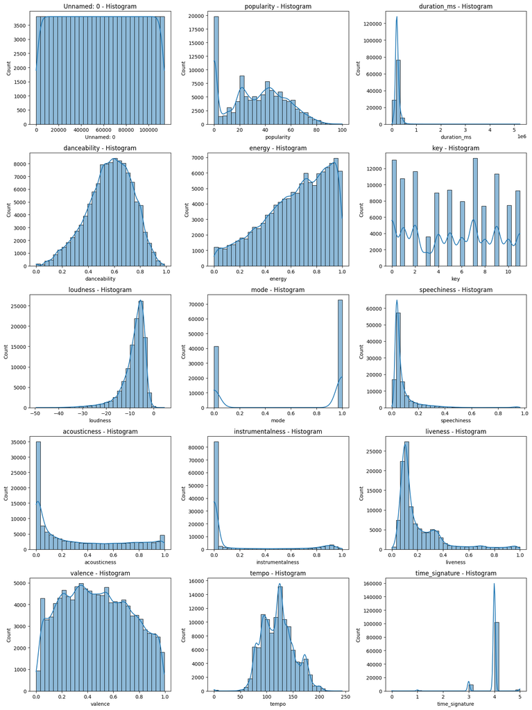

```python
# Select numeric columns
num_features = sdata.select_dtypes(include='number').columns.tolist()
sdata['popularity_bin'] = pd.cut(sdata['popularity'], bins=[0, 20, 50, 80, 100],
                       labels=["0–20", "21–50", "51–80", "81–100"])

# === HISTOGRAMS ===
n_cols = 3
n_rows = (len(num_features) + n_cols - 1) // n_cols
fig, axs = plt.subplots(n_rows, n_cols, figsize=(15, 4 * n_rows))
axs = axs.flatten()

for i, feature in enumerate(num_features):
    sns.histplot(sdata[feature], ax=axs[i], kde=True, bins=30)
    axs[i].set_title(f'{feature} - Histogram')

for j in range(i + 1, len(axs)):
    fig.delaxes(axs[j])

plt.tight_layout()
plt.show()
```

# Visualize boolean feature

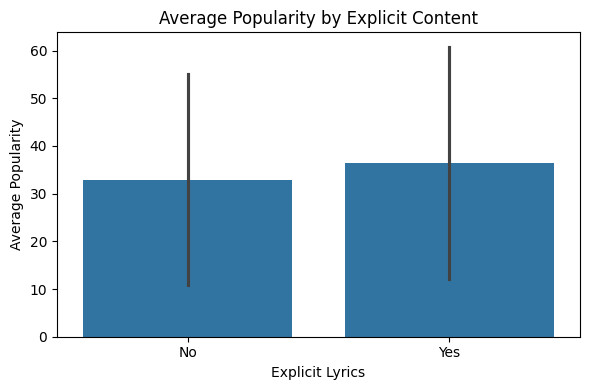

```python
# Create bar plot
plt.figure(figsize=(6, 4))
sns.barplot(data=sdata, x='explicit', y='popularity', ci='sd')

plt.title('Average Popularity by Explicit Content')
plt.xlabel('Explicit Lyrics')
plt.ylabel('Average Popularity')
plt.xticks([0, 1], ['No', 'Yes'])
plt.tight_layout()
plt.show()
```

# Insights

# Cleaning the raw data steps

```python
# Convert popularity to binary labels (1 = Popular, 0 = Not Popular)
sdata["popularity_label"] = (sdata["popularity"] > 80).astype(int)

# Normalize loudness (since values are mostly negative decibels)
sdata["loudness"] = (sdata["loudness"] - sdata["loudness"].min()) / (
    sdata["loudness"].max() - sdata["loudness"].min()
)
# Normalize tempo
sdata["tempo"] = (sdata["tempo"] - sdata["tempo"].min()) / (
    sdata["tempo"].max() - sdata["tempo"].min()
)
# Converting duration_ms to durations which is minutes & seconds for clarity
sdata["duration"] = sdata["duration_ms"] / 60000  # convert ms to minutes

# Check if 'track_id' and 'Unnamed: 0' columns exist before dropping
if 'track_id' in sdata.columns and 'Unnamed: 0' in sdata.columns:
    sdata = sdata.drop(columns=["track_id", "Unnamed: 0"])
elif 'track_id' in sdata.columns:
    sdata = sdata.drop(columns=["track_id"])
elif 'Unnamed: 0' in sdata.columns:
    sdata = sdata.drop(columns=["Unnamed: 0"])
# If neither column exists, the drop operation is skipped.

# Drop original text columns after encoding
sdata_clean = sdata.drop(columns=['artists', 'album_name', 'track_name',
              'popularity_bin', 'track_genre', 'duration_ms', 'time_signature'])
# Keeping original 'popularity' for examination of distribution and feature importance

# Remove duplicates
data_clean = sdata_clean.drop_duplicates()

# Confirm dataset cleanup
print(data_clean.info())
print(data_clean.head())
```

```
<class 'pandas.core.frame.DataFrame'>
Index: 86706 entries, 0 to 113999
Data columns (total 15 columns):
 #   Column            Non-Null Count  Dtype
---  ------            --------------  -----
 0   popularity        86706 non-null  int64
 1   explicit          86706 non-null  bool
 2   danceability      86706 non-null  float64
 3   energy            86706 non-null  float64
 4   key               86706 non-null  int64
 5   loudness          86706 non-null  float64
 6   mode              86706 non-null  int64
 7   speechiness       86706 non-null  float64
 8   acousticness      86706 non-null  float64
 9   instrumentalness  86706 non-null  float64
 10  liveness          86706 non-null  float64
 11  valence           86706 non-null  float64
 12  tempo             86706 non-null  float64
 13  popularity_label  86706 non-null  int64
 14  duration          86706 non-null  float64
dtypes: bool(1), float64(10), int64(4)
memory usage: 10.0 MB
None
   popularity  explicit  danceability  energy  key  loudness  mode  \
0          73     False         0.676  0.4610    1  0.791392     0
1          55     False         0.420  0.1660    1  0.597377     1
2          57     False         0.438  0.3590    0  0.736123     1
3          71     False         0.266  0.0596    0  0.573701     1
4          82     False         0.618  0.4430    2  0.737103     1

   speechiness  acousticness  instrumentalness  liveness  valence     tempo  \
0       0.1430        0.0322          0.000001    0.3580    0.715  0.361245
1       0.0763        0.9240          0.000006    0.1010    0.267  0.318397
2       0.0557        0.2100          0.000000    0.1170    0.120  0.313643
3       0.0363        0.9050          0.000071    0.1320    0.143  0.746758
4       0.0526        0.4690          0.000000    0.0829    0.167  0.492863

   popularity_label  duration
0                 0  3.844433
1                 0  2.493500
2                 0  3.513767
3                 0  3.365550
4                 1  3.314217
```

# Ensure normalization was successful by looking at highest & lowest values

```python
# Features to analyze
features = ["loudness", "tempo"]

# Finding Min and Max for each feature
high_low_values = {}
for feature in features:
    high_low_values[feature] = {
        "Minimum": data_clean[feature].min(),
        "Maximum": data_clean[feature].max()
    }

# Convert to DataFrame for better readability
high_low_df = pd.DataFrame(high_low_values)

# Display the results
print(high_low_df)
```

```
         loudness  tempo
Minimum       0.0    0.0
Maximum       1.0    1.0
```

### The min and max are the expected range.

# Examining Distribution of target variable 'popularity' (scores 0-100)

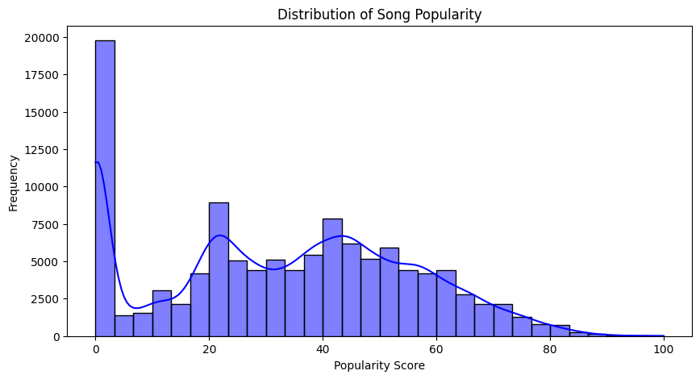

```python
# Plot distribution of 'popularity' to show distribution
plt.figure(figsize=(10, 5))
sns.histplot(sdata_clean["popularity"], bins=30, kde=True, color="blue")
plt.title("Distribution of Song Popularity")
plt.xlabel("Popularity Score")
plt.ylabel("Frequency")
plt.show()
```

# Examining the correlation heatmap to show the relationships of variables within popularity_label == 1

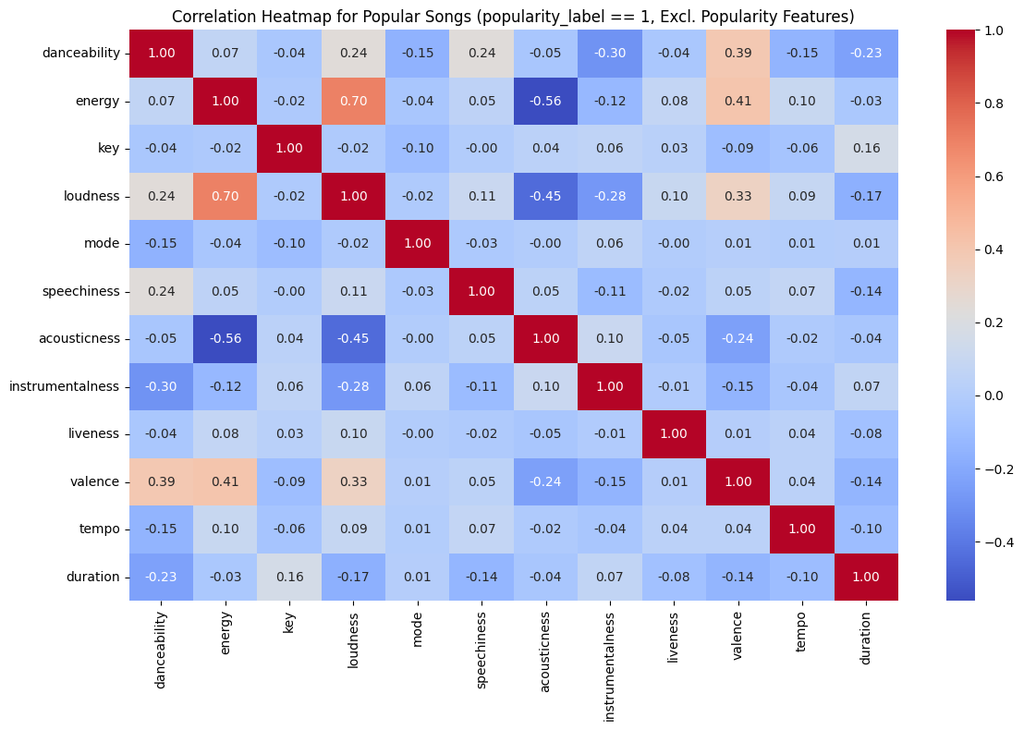

```python
# Filter to only popular songs
popular_songs = sdata_clean[sdata_clean['popularity_label'] == 1]

# Select only numeric features
numeric_df = popular_songs.select_dtypes(include=np.number)

# Drop any popularity-related columns
numeric_df = numeric_df.drop(columns=[col for col in numeric_df.columns if 'popularity' in col])

# Compute and plot correlation matrix
plt.figure(figsize=(12, 8))
sns.heatmap(numeric_df.corr(), annot=True, fmt=".2f", cmap="coolwarm")
plt.title("Correlation Heatmap for Popular Songs (popularity_label == 1, Excl. Popularity Features)")
plt.tight_layout()
plt.savefig("correlation_heatmap.png")
plt.show()
```

This heatmap displays the correlations between numerical audio features for songs labeled as popular (`popularity_label == 1`).

Strong positive relationships are observed between `energy` and `loudness` (0.70), and between `valence` and both `danceability` (0.39) and `energy` (0.41), suggesting that popular songs are typically loud, energetic, and emotionally upbeat.

On the other hand, `acousticness` is moderately negatively correlated with both `energy` (−0.56) and `loudness` (−0.45), reinforcing that popular songs tend to be less acoustic.

While `duration` shows weak negative correlation with `popularity` (−0.08), `danceability` (−0.23), and `loudness` (−0.17), suggesting that longer songs may be slightly less dynamic or engaging overall.

# Examine Feature Frequency for 'popularity_label ==1' to determine how often the comparable features occur

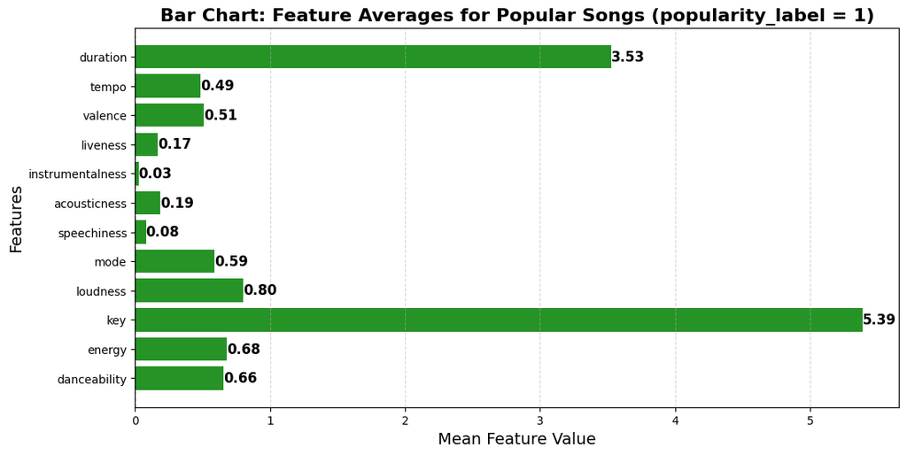

```python
# Selecting numerical features for visualization
numerical_features = ['danceability', 'energy', 'key','loudness', 'mode',
                      'speechiness', 'acousticness', 'instrumentalness', 'liveness', 'valence', 'tempo', 'duration' ]

# Filter for high popularity based on binary label
high_pop_df = sdata_clean[sdata_clean["popularity_label"] == 1]

# Compute mean of each numerical feature
diverging_data = high_pop_df[numerical_features].mean()

# Define color mapping (green for positive, red for negative deviation from 0)
colors = ['green' if value >= 0 else 'red' for value in diverging_data]

# Create a diverging bar chart
plt.figure(figsize=(12, 6))
bars = plt.barh(diverging_data.index, diverging_data.values, color=colors, alpha=0.85)

# Add annotations
for bar in bars:
    plt.text(bar.get_width(), bar.get_y() + bar.get_height()/2,
             f'{bar.get_width():.2f}',
             va='center', ha='left' if bar.get_width() > 0 else 'right',
             fontsize=12, fontweight='bold')

# Styling
plt.axvline(0, color='black', linestyle='--', linewidth=1)
plt.xlabel("Mean Feature Value", fontsize=14)
plt.ylabel("Features", fontsize=14)
plt.title("Bar Chart: Feature Averages for Popular Songs (popularity_label = 1)", fontsize=16, fontweight='bold')
plt.grid(axis='x', linestyle='--', alpha=0.5)

plt.show()
```

This bar chart shows the average values of key musical features for songs labeled as popular (popularity_label == 1).

Moderate values in mode (0.59), valence (0.51), and tempo (0.49) suggest these songs are typically upbeat and mid-tempo.

Low values for instrumentalness (0.03), speechiness (0.08), and acousticness (0.19) imply that popular tracks are less likely to be instrumental, spoken-word, or acoustic.

```python
# Compute numerical statistics and print the stats as a chart
numerical_stats = sdata_clean[numerical_features].describe().round(2)
# Display
numerical_stats
```

|  | danceability | energy | key | loudness | mode | speechiness | acousticness | instrumentalness | liveness | valence | tempo | duration |
| --- | --- | --- | --- | --- | --- | --- | --- | --- | --- | --- | --- | --- |
| count | 114000.00 | 114000.00 | 114000.00 | 114000.00 | 114000.00 | 114000.00 | 114000.00 | 114000.00 | 114000.00 | 114000.00 | 114000.00 | 114000.00 |
| mean | 0.57 | 0.64 | 5.31 | 0.76 | 0.64 | 0.08 | 0.31 | 0.16 | 0.21 | 0.47 | 0.50 | 3.80 |
| std | 0.17 | 0.25 | 3.56 | 0.09 | 0.48 | 0.11 | 0.33 | 0.31 | 0.19 | 0.26 | 0.12 | 1.79 |
| min | 0.00 | 0.00 | 0.00 | 0.00 | 0.00 | 0.00 | 0.00 | 0.00 | 0.00 | 0.00 | 0.00 | 0.00 |
| 25% | 0.46 | 0.47 | 2.00 | 0.73 | 0.00 | 0.04 | 0.02 | 0.00 | 0.10 | 0.26 | 0.41 | 2.90 |
| 50% | 0.58 | 0.68 | 5.00 | 0.79 | 1.00 | 0.05 | 0.17 | 0.00 | 0.13 | 0.46 | 0.50 | 3.55 |
| 75% | 0.70 | 0.85 | 8.00 | 0.82 | 1.00 | 0.08 | 0.60 | 0.05 | 0.27 | 0.68 | 0.58 | 4.36 |
| max | 0.98 | 1.00 | 11.00 | 1.00 | 1.00 | 0.96 | 1.00 | 1.00 | 1.00 | 1.00 | 1.00 | 87.29 |

# Use RandomForestRegressor to analyse Feature Importance on already popular songs to determine what contributes to the popularity

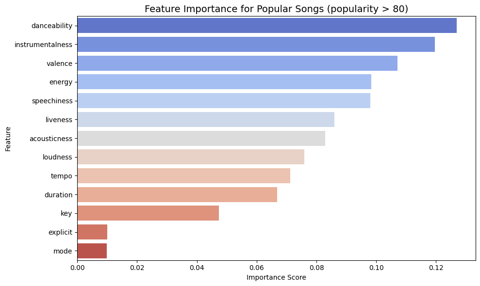

```python
# Step 1: Subset songs where popularity > 80
popular_songs = sdata_clean[sdata_clean['popularity'] > 80].copy()

# Step 2: Define features and target
X = popular_songs.drop(columns=['popularity', 'popularity_label'])
y = popular_songs['popularity']

# Step 3: Train RandomForestRegressor
rf_model = RandomForestRegressor(n_estimators=100, random_state=42)
rf_model.fit(X, y)

# Step 4: Extract feature importances
importance_df = pd.DataFrame({
    'Feature': X.columns,
    'Importance': rf_model.feature_importances_
}).sort_values(by='Importance', ascending=False)

# Step 5: Plot
plt.figure(figsize=(10, 6))
sns.barplot(x='Importance', y='Feature', data=importance_df, palette='coolwarm')
plt.title('Feature Importance for Popular Songs (popularity > 80)', fontsize=14)
plt.xlabel('Importance Score')
plt.ylabel('Feature')
plt.tight_layout()
plt.show()
```

This bar chart displays the feature importance results from a `RandomForestRegressor` model trained on songs with popularity scores above 80.

Other significant contributors include `liveness`, `acousticness`, and `duration`, indicating that tracks with subtle live elements, moderate acoustic properties, and certain length ranges also influence popularity.

In contrast, features such as `mode`, `explicit`, and `key` exhibit minimal importance, suggesting that these factors have limited impact on the popularity of already well-received songs.

These insights can inform targeted feature selection for models aimed at optimizing or predicting song popularity within the upper threshold.

# Create a Diverging Bar Chart to examine the features that postively and negatively correlate with already popular songs

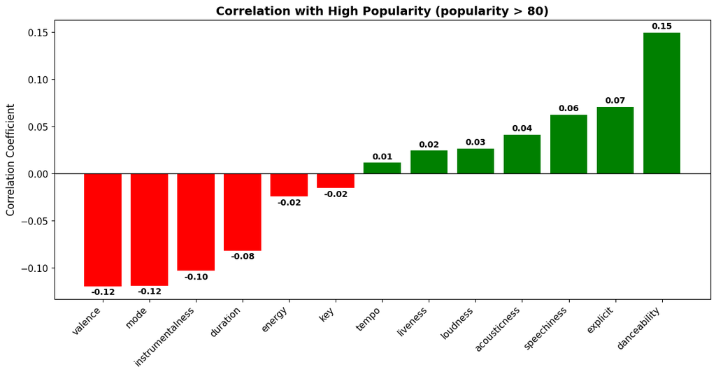

```python
# Compute correlations with continuous popularity
corr_with_pop = popular_songs.corr()['popularity'].drop(['popularity', 'popularity_label'], errors='ignore')

# Sort values
corr_sorted = corr_with_pop.sort_values()

# Assign diverging bar colors
colors = ['green' if val > 0 else 'red' for val in corr_sorted]

# Plot
plt.figure(figsize=(14, 6))
bars = plt.bar(corr_sorted.index, corr_sorted.values, color=colors)

# Annotate bars
for bar in bars:
    height = bar.get_height()
    plt.text(bar.get_x() + bar.get_width() / 2,
             height + 0.002 if height > 0 else height - 0.002,
             f'{height:.2f}',
             ha='center', va='bottom' if height > 0 else 'top',
             fontsize=10, fontweight='bold')

# Axis styling
plt.axhline(0, color='black', linewidth=1)
plt.xticks(rotation=45, ha='right', fontsize=11)
plt.yticks(fontsize=11)
plt.title('Correlation with High Popularity (popularity > 80)', fontsize=14, fontweight='bold')
plt.ylabel('Correlation Coefficient', fontsize=12)

plt.show()
```

This bar chart illustrates the direction and strength of correlations between audio features and high popularity (defined as songs with a popularity score above 80).

On the other hand, features such as `mode`, `valence`, and `instrumentalness` are negatively correlated, implying that popular songs tend to be less likely to be in major keys, overly positive in tone, or instrumental.

These trends can inform both predictive modeling and content strategy in music analytics.

# Examine the Distribution of the binary variable popularity_label with popularity_label == 1 is popularity >80, popularity_label == 0 is popularity <=80

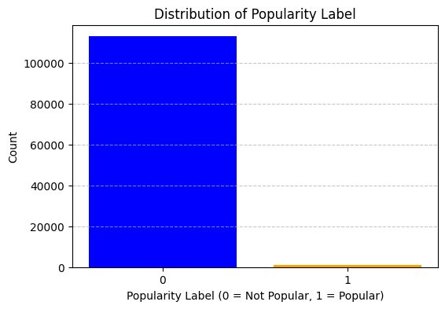

```python
# Examine the distribution of popularity_label
if 'popularity_label' in sdata_clean.columns:
    # Count occurrences of each category (0 and 1)
    popularity_counts = sdata_clean['popularity_label'].value_counts()

    # Create bar plot
    plt.figure(figsize=(6, 4))
    plt.bar(popularity_counts.index.astype(str), popularity_counts.values, color=['blue', 'orange'])
    plt.xlabel("Popularity Label (0 = Not Popular, 1 = Popular)")
    plt.ylabel("Count")
    plt.title("Distribution of Popularity Label")
    plt.grid(axis='y', linestyle='--', alpha=0.7)
    plt.show()
else:
    print("Column 'popularity_label' not found in the dataset. Please ensure it exists.")
```

A HIGHLY imbalanced dataset for our predictive purpose requires balancing using SMOTE (Synthetic Minority Over-sampling Technique) which will retain the accuracy of the associations while balancing the data for a larger analysis pool.

```python
# Count the number of popular songs (popularity_label == 1)
popular_count = sdata_clean[sdata_clean["popularity_label"] == 1].shape[0]
unpopular_count = sdata_clean[sdata_clean["popularity_label"] == 0].shape[0]
print(f"Number of popular songs (popularity_label == 1): {popular_count}")
print(f"Number of unpopular songs (popularity_label == 0): {unpopular_count}")
```

```
Number of popular songs (popularity_label == 1): 954
Number of unpopular songs (popularity_label == 0): 113046
```